# chapter-6

Early Social Structure and Strain Theories of Crime

## August Comte

Coined the term “Sociology”

Developed the concepts:

**Social Statics:** Study of *social order and stability* (e.g., structures, institutions, hierarchies).

**Social Dynamics:** Study of *social change and progress* (e.g., evolution and development of social institutions).

Example: Civil Rights Movement

[figure not shown]

## Adolphe Quetelet (KAH-tay-lay)

Belgian mathematician and sociologist; introduced statistical methods to the social sciences.

Relative Deprivation

The perception of inequality or unfairness when individuals/groups compare their status to others in close proximity, fueling frustration and deviant behavior.

Example: Washington DC and High crime rates, neighborhoods are adjacent to affluent areas reflect inequality and contribute to deprivation.

[figure not shown]

## Relative Deprivation

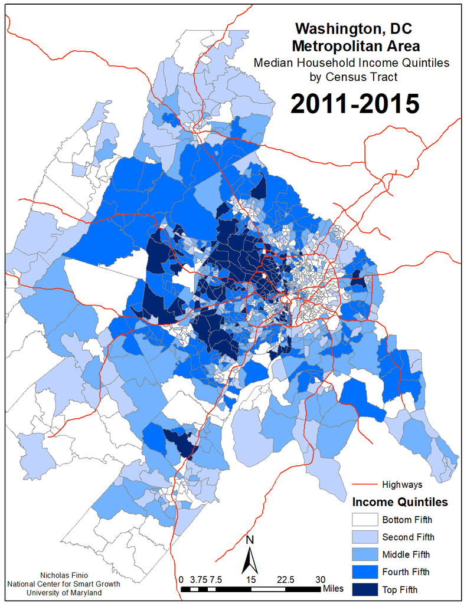

Image: Greater Greater Washington

## Émile Durkheim

French sociologist (1858–1917), often called one of the founders of modern sociology

Emphasized empirical research and the importance of objective data (e.g., statistics) in studying social phenomena

His concepts (e.g., anomie) remain central to sociological theory, informing research on social integration, norms, and collective behavior

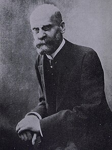

## Émile Durkheim and Anomie

Anomie

*A state of social instability (“normlessness”) where societal norms, values, and regulations break down*, leading to: confusion about acceptable behavior, alienation from community, increased deviance/crime

Key Causes/Triggers:

1.) Rapid Social Change

Industrialization, urbanization, or technological disruption

2.) Economic Crises

Sudden wealth inequality or unemployment (e.g., Great Depression)

3.) Cultural Shifts

Collapse of traditional values without new norms to replace them

## Émile Durkheim and Anomie

Collective Conscious the degree in which individuals of society are think alike or have similar norms and values. Leads to social cohesion.

Industrialization led Mechanical Societies into Organic Societies

| Mechanical Societies 🌾 | Organic Societies 🏙️ |
| --- | --- |
| Primitive | Modern |
| Rural | Urban |
| Agricultural based | Industrial based |
| Simple division of labor | Complex division of labor (specialization focused) |
| Law used to enforce conformity | Law used to regulate division interactions |
| Stronger collective conscious | Weaker collective consciousness |

## Émile Durkheim and Anomie

1️⃣ Rapid Social Change (e.g., industrialization, economic booms/busts, technological disruption) ➡️

2️⃣ Breakdown of Norms (e.g., old rules lose relevance; new norms are absent/weak) ➡️

3️⃣ Anomie (i.e., “normlessness” – society fails to regulate goals/behavior) ➡️

🏁 Social Consequences ️= ⬇️ Collective Conscious

## Émile Durkheim and Suicide

In *Suicide* (1897), Durkheim examined how social integration and regulation affect suicide rates

He examined popular religious groups in that time, and found that Catholics, with *stronger social bonds*, had lower suicide rates than Protestants, *who experienced weaker collective ties*

Showed that when social norms weaken (i.e., anomie occurs) the risk of suicide increases. Thus, social factors influence individual behavior

Keep in mind that in 1897, societal attitudes toward suicide were still largely dogmatic, often regarding it both as a grave moral failing and a criminal act

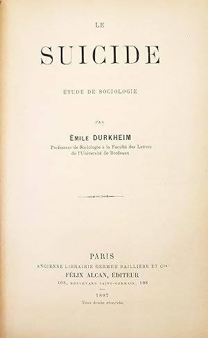

## Émile Durkheim and Suicide

**Why this matters:**

1️⃣ Societal conditions can drive individual behaviors like suicide or other forms of deviance

2️⃣ Which emphasizes that personal acts or crimes often stem from broader social forces such as weakened communal bonds or unclear expectations

3️⃣ Durkheim’s work shifts focus away from purely individual explanations(e.g., mental illness) and toward understanding how social structures, norms, and the level of integration within a community influence behavior

## Key point here!!

Durkheim’s concept of anomie and the importance of collective consciousness highlight that broader social structures — *rather than purely personal factors* — can powerfully shape individual behaviors.

# Group Discussion!!!!

## Group Discussion

`10:00`

During the COVID-19 pandemic, lockdowns disrupted established social structures (e.g., remote work, virtual education, restricted social interaction). In your view, did these abrupt shifts in societal norms create widespread feelings of anomie (normlessness or alienation)?

If yes, what new or intensified forms of deviance emerged as a result of this destabilization?

If no, what societal mechanisms prevented anomie from taking hold?

Pick one and make an argument for your choice. Elect one speaker to present your point.

# Strain Theories

## A Hypothetical

Who achieved success in American Society?

- Scenario A. John, who has a PhD in physics, lives in a one-bedroom apartment because his postdoc position pays 25k a year, additionally has 150,000 in student debt
- Scenario B. Joe, who is a relatively successful drug dealer who lives in a four-bedroom home, drives a Hummer, dropped out of high school in 10th grade, and makes more than 90k a year.

## Merton’s Strain Theory

Robert K. Merton (1938)

Expanded on Durkheim’s concept of anomie

A state of “normlessness” caused by rapid social change (e.g., industrialization), where societal rules collapse, leading to deviance

Merton’s Concept of Strain

Anomie is the structural strain itself - the imbalance between society’s emphasis on cultural goals (wealth, success) and the lack of access to legitimate institutionalized means (education, jobs) to achieve them, which leads to deviance

## Merton’s Strain Theory

Cultural Goals: Societal aspirations (e.g., wealth, success)

Institutionalized Means: Legitimate paths to achieve goals (e.g., education, hard work)

Strain: Disconnect between cultural goals and access to institutionalized means

Anomie: Normlessness due to societal pressure/breakdown which leads to deviance

## Merton’s Strain Theory

These adaptations reflect responses to the strain between society’s emphasis on success (goals) and unequal access to legitimate opportunities (means)

Conformity: Accepts both societal goals and legitimate means (e.g., pursuing wealth through education/hard work)

Innovation: Accepts cultural goals but uses illegitimate means to achieve them (e.g., theft, fraud)

Ritualism: Abandons cultural goals but rigidly follows institutionalized means (e.g., bureaucratic workers “going through the motions”)

Retreatism: Rejects both goals and means, withdrawing from society (e.g., substance abuse, homelessness)

Rebellion: Rejects societal goals and means, replacing them with new ones (e.g., revolutionaries seeking to overthrow systems)

## Five Adaptations to Strain

| Mode | Accept Goals? | Accept Means? | Example |
| --- | --- | --- | --- |
| Conformity | Yes | Yes | Pursue career via education |
| Innovation | Yes | No | Drug trade for wealth |
| Ritualism | No | Yes | Bureaucrat follows rules rigidly |
| Retreatism | No | No | Substance abuse, dropout |
| Rebellion | *Replace* | *Replace* | Revolutionary movements |

## General Strain Theory

Robert Agnew (1992)

Key Shift from Merton:

Strain is not just structural (goals vs. means) but individual-level

Strain ➡️ Negative emotion (anger) ➡️ deviance

## Three Types of Strain

1️⃣ Failure to Achieve Goals

Disjunction between expectations and reality

Example: Poor grades despite effort

2️⃣ Removal of Positive Stimuli

Loss of valued resources

Example: Loss of a loved one, breakup

3️⃣ Presence of Negative Stimuli

Exposure to harm

Example: Abuse, bullying, discrimination.

## How Strain Leads to Deviance

Strain ➡️ Negative emotion (anger) ➡️ deviance

The link between negative emotion and deviance depends on coping mechanisms:

⑴ Legitimate Coping: Therapy, exercise, social support

⑵ Illegitimate Coping: Drug use, violence, theft

Lack of access to legitimate coping resources (e.g., financial stability, mentorship, mental health support) increases the likelihood of deviant behavior.

## Comparing Merton and GST

| Merton (1938) | GST (Agnew, 1992)️ |
| --- | --- |
| Structural goals | Individual-level strains |
| Inability to achieve goals legitimately | Negative relationships/experiences |
| 5 modes of adaptation | Anger/frustration and coping mechanisms |

# Group Discussion!!!!

## Group Discussion

`10:00`

With what we just learned about General Strain Theory, come up with an idea for a product (e.g., app, social media group, website, etc…) that would help individuals access legitimate coping resources (e.g., therapy, exercise, social support) during negative emotional events (like anger) before they escalate to deviance.

For example, a meditation app that alerts users during heart rate spikes from stress induced anxiety.

Have fun with it! Think outside the 📦

Elect one speaker to present your point.

## Have a great weekend!

[figure not shown]

image: giphy